# Agrupamento sobre dados da UFCG

Nessa análise, iremos dividir as Unidades Acadêmicas da UFCG em diferentes grupos, as variáveis utilizadas para fazer esse agrupamento serão exploradas a seguir. Antes de visualizar os dados é importante saber que **percentis** são medidas que dividem a amostra ordenada (por ordem crescente dos dados) em 100 partes, cada uma com uma percentagem de dados aproximadamente igual.

#### Funcionários na UA que não são professores

```r
p = ggplot(ufcg_uas_sumario, aes(x=UORG_LOTACAO,
             y=Outro,
             text = paste("UA:",UORG_LOTACAO,
                            "\nQuantidade:",
                            Outro))) +
     labs(title = "Funcionários que não são professores", y = "Quantidade", x = "UA")+
    theme(legend.position="none") +
  geom_point(colour = "#882C3E") + coord_flip()
ggplotly(p, tooltip = "text")
```

[interactive chart not shown]

#### Professores com carga horária 20h/semana

```r
p = ggplot(ufcg_uas_sumario, aes(x=UORG_LOTACAO,
             y=`Professor 20h`,
             text = paste("UA:",UORG_LOTACAO,
                            "\nQuantidade:",
                            `Professor 20h`))) +
     labs(title = "Professores com carga horária 20h/semana", y = "Quantidade", x = "UA")+
    theme(legend.position="none") +
  geom_point(colour = "#50dd66") + coord_flip()
ggplotly(p, tooltip = "text")
```

[interactive chart not shown]

Aqui, vemos que a maioria das Unidade Acadêmicas não possui nenhum professor com carga horária de 20h/semana, mas a *Unidade Acadêmica de Medicina* chama atenção com 65 professores com essa carga horária.

#### Professores com carga horária 40h/semana na UA, sejam eles Dedicação Exclusiva ou não

```r
p = ggplot(ufcg_uas_sumario, aes(x=UORG_LOTACAO,
             y=`Professor 40h ou DE`,
             text = paste("UA:",UORG_LOTACAO,
                            "\nQuantidade:",
                            `Professor 40h ou DE`))) +
     labs(title = "Professores com carga horária 40h/semana, sejam eles Dedicação Exclusiva ou não", y = "Quantidade", x = "UA")+
    theme(legend.position="none") +
  geom_point(colour = "#ED6471") + coord_flip()
ggplotly(p, tooltip = "text")
```

[interactive chart not shown]

#### 25 percentil da idade dos funcionários *no cargo*

```r
p = ggplot(ufcg_uas_sumario, aes(x=UORG_LOTACAO,
             y=idade_25perc,
             text = paste("UA:",UORG_LOTACAO,
                            "\n25 percentil:",
                            idade_25perc))) +
     labs(title = "25 percentil da idade dos funcionários no cargo", y = "25 Percentil", x = "UA")+
    theme(legend.position="none") +
  geom_point(colour = "#b0b3cc") + coord_flip()
ggplotly(p, tooltip = "text")
```

[interactive chart not shown]

#### Idade mediana dos funcionários *no cargo*

```r
p = ggplot(ufcg_uas_sumario, aes(x=UORG_LOTACAO,
             y=idade_mediana,
             text = paste("UA:",UORG_LOTACAO,
                            "\nIdade Mediana:",
                            idade_mediana))) +
     labs(title = "Idade mediana dos funcionários no cargo", y = "Idade mediana", x = "UA")+
    theme(legend.position="none") +
  geom_point(colour = "#5f6694") + coord_flip()
ggplotly(p, tooltip = "text")
```

[interactive chart not shown]

A maioria dos funcionários no cargo está entre 6 e 9.

#### 75 percentil da idade dos funcionários *no cargo*

```r
p = ggplot(ufcg_uas_sumario, aes(x=UORG_LOTACAO,
             y=`idade_75perc`,
             text = paste("UA:",UORG_LOTACAO,
                            "\n75 percentil:",
                            `idade_75perc`))) +
     labs(title = "75 percentil dos funcionários no cargo", y = "75 percentil", x = "UA")+
    theme(legend.position="none") +
  geom_point(colour = "#12131c") + coord_flip()
ggplotly(p, tooltip = "text")
```

[interactive chart not shown]

*Exemplo de interpretação: Na Unidade Acadêmica de Sistemas e computação, 75% dos funcionários tem 22.09 anos ou menos na profissão.*

### Escolha do número K

Para agrupar as unidades em diferentes grupos, o primeiro passo é descobrir a quantidade de grupos ideal. Existem diversas formas de calcular esse número, aqui, iremos utilizar a medida da razão [betweenss/totss](https://github.com/nazareno/ciencia-de-dados-1/blob/master/3-Agrupamento-e-PCA/2-kmeans-e-mais-exemplos.Rmd#betweentotss).

Antes, vamos fazer uma transformação nos dados com o objetivo de facilitar a identificação dos grupos. A proporção de diferença entre as observações será mantida.

```r
ufcg.scaled = ufcg_uas_sumario %>%
  mutate_at(vars(Outro,
                 `Professor 20h`,
                 `Professor 40h ou DE`,
                 idade_25perc,
                 idade_mediana,
                 idade_75perc),
            funs(log))
```

#### Betweenss/totss

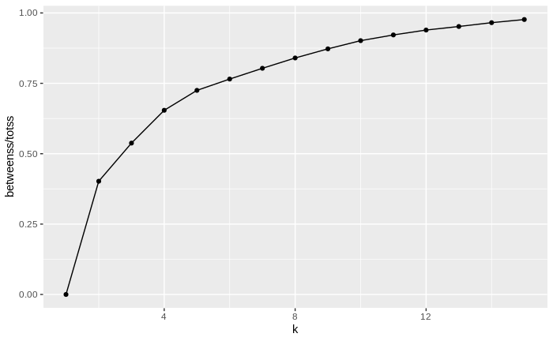

```r
set.seed(31)
#
explorando_k = tibble(k = 1:15) %>%
  group_by(k) %>%
  do(
    kmeans(NaRV.omit(select(ufcg.scaled, -UORG_LOTACAO)),
           centers = .$k,
           nstart = 20) %>%
      glance()
  )
explorando_k %>%
  ggplot(aes(x = k, y = betweenss / totss)) +
  geom_line() +
  geom_point()
```

Observando o gráfico, a linha entre 0 e 4 cresce bastante, porém, depois do 4, o crescimento não é muito significativo, então, iremos escolher a quantidade de grupos como sendo 4 (k = 4).

### K-means

Vamos aplicar o algoritmo K-means com a quantidade de clusters sendo igual à 4.

```r
set.seed(31)
n_clusters = 4
km = ufcg_uas_sumario %>%
  select(-UORG_LOTACAO) %>%
  kmeans(centers = n_clusters, nstart = 20)
unidades_agrupadas = km %>%
  augment(ufcg.scaled) %>%
  gather(key = "variável",
         value = "valor",
         -UORG_LOTACAO,
         -.cluster)
p = ggplot(unidades_agrupadas, aes(x=`variável`,
             y=valor,
             text = paste("UA:",UORG_LOTACAO),
             group = UORG_LOTACAO,
             colour = .cluster)) +
     labs(title = "Agrupamento")+
    theme(legend.position="none") +
  geom_point() + coord_flip() + facet_wrap(~ .cluster)
ggplotly(p, tooltip = "text")
```

[interactive chart not shown]

Os grupos se comportam de forma semelhante, mas podemos classificar da seguinte maneira: * **Grupo 1:** possue as unidades acadêmicas onde há os valores mais baixos em todas as variáveis. * Exemplos: * Unidade Acadêmica Matemática e estatística * Unidade Acadêmica de Letras * Unidade Acadêmica de Desenho Industrial * **Grupo 2:** só possue duas unidades acadêmicas. As duas unidades se destacam por serem as que mais possuem professores com a carga horária de 20h semanais. * Unidade Acadêmica de Medicina * Unidade Acadêmica de Ciências da Vida * **Grupo 3:** possue as unidades acadêmicas onde os professores possuem o maior valor na variável *Idade 75 percentil* * Exemplos: * Unidade Acadêmica de Engenharia Química * Unidade Acadêmica de Medicina Veterinária * Unidade Acadêmica de Mineração e Geologia * **Grupo 4:** esse grupo se destaca na variável *Professor 40h ou DE*, pois os valores nessa variável são os maiores entre os 4 grupos. * Exemplo: * Unidade Acadêmica de Ciências Sociais * Unidade Acadêmica de Direito * Unidade Acadêmica de Enfermagem